# IE6400 Foundations for Data Analytics Engineering

#### Exercise 14 Histogram Revisited

This histogram shows the distribution of the weight feature along with the mean and median. Notice that the mean is not equal to the median, which means that the feature is not normally distributed.

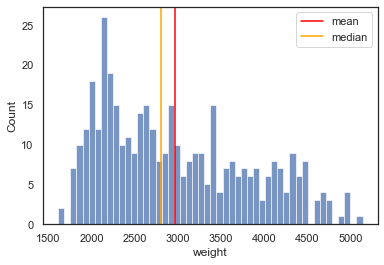

```python
 # histogram using seaborn
import matplotlib.pyplot as plt
import seaborn as sns
import numpy as np

mpg_df = sns.load_dataset("mpg")
ax = sns.histplot(mpg_df.weight,
                  bins = 50,
                  kde = False)

# `label` defines the name used in legend
plt.axvline(x = np.mean(mpg_df.weight),
            color = 'red',
            label = 'mean')
plt.axvline(x = np.median(mpg_df.weight),
            color = 'orange',
            label = 'median')
plt.legend(loc = 'upper right')
plt.show()
```

#### Exercise 15 Creating and Exploring a Static Box Plot

In this exercise, we will create a box plot to analyze the relationship between model_ year and mileage using the mpg dataset. We'll analyze manufacturing efficiency and the mileage of vehicles over a period of years. To do so, let's go through the following steps:

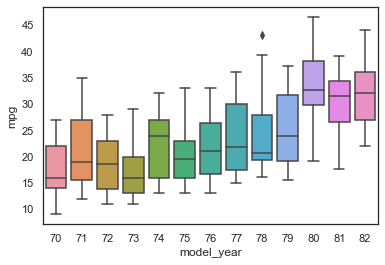

```python
import seaborn as sns
import matplotlib.pyplot as plt

mpg_df = sns.load_dataset("mpg")
# box plot: mpg(mileage) vs model_year
sns.boxplot(x = 'model_year',
            y = 'mpg',
            data = mpg_df)
plt.show()
```

Notice that the mileage improved substantially in the 80s compared to the 70s. Let's add another feature to our mpg DataFrame that denotes whether the car was manufactured in the 70s or 80s.

Modify the mpg DataFrame by creating a new feature, model_decade:

```python
import numpy as np

# creating a new feature 'model_decade'
mpg_df['model_decade'] = np.floor(mpg_df.model_year/10)*10
mpg_df['model_decade'] = mpg_df['model_decade'].astype(int)
mpg_df.tail()
```

|  | mpg | cylinders | displacement | horsepower | weight | acceleration | model_year | origin | name | model_decade |
| --- | --- | --- | --- | --- | --- | --- | --- | --- | --- | --- |
| 393 | 27.0 | 4 | 140.0 | 86.0 | 2790 | 15.6 | 82 | usa | ford mustang gl | 80 |
| 394 | 44.0 | 4 | 97.0 | 52.0 | 2130 | 24.6 | 82 | europe | vw pickup | 80 |
| 395 | 32.0 | 4 | 135.0 | 84.0 | 2295 | 11.6 | 82 | usa | dodge rampage | 80 |
| 396 | 28.0 | 4 | 120.0 | 79.0 | 2625 | 18.6 | 82 | usa | ford ranger | 80 |
| 397 | 31.0 | 4 | 119.0 | 82.0 | 2720 | 19.4 | 82 | usa | chevy s-10 | 80 |

Now, let's redraw our box plot to look at mileage distribution for the two decades:

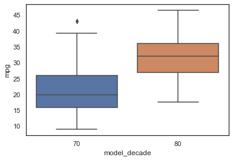

```python
# a boxplot with multiple classes
sns.boxplot(x = 'model_decade',
            y = 'mpg',
            data = mpg_df)
plt.show()
```

We can also add another feature, say, region of origin, and see how that affects the relationship between mileage and manufacturing time, the two features we have been considering so far.

Use the hue parameter to group by origin:

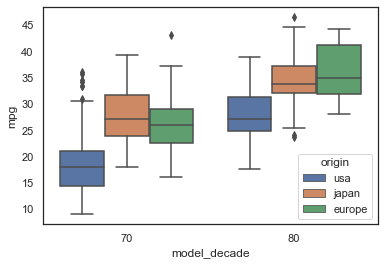

```python
 # boxplot: mpg (mileage) vs model_decade
sns.boxplot(x = 'model_decade',
            y = 'mpg',
            data = mpg_df,
            hue = 'origin')
plt.show()
```

As we can see, according to the mpg dataset, in the 70s and early 80s, Europe and Japan produced cars with better mileage than the USA.

#### Exercise 16 Creating a Static Violin Plot

In this exercise, we will use the mpg dataset and generate a violin plot depicting the detailed variation of mileage (mpg) based on model_decade and region of origin:

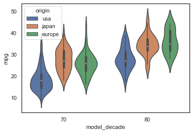

```python
import seaborn as sns
import numpy as np
import matplotlib.pyplot as plt

mpg_df = sns.load_dataset("mpg")

# creating the feature 'model_decade'
mpg_df['model_decade'] = np.floor(mpg_df.model_year/10)*10
mpg_df['model_decade'] = mpg_df['model_decade'].astype(int)

# code for violinplots
sns.violinplot(x = 'model_decade',
               y = 'mpg',
               data = mpg_df,
               hue = 'origin')
plt.show()
```

- We can see here that, during the 70s, while most vehicles in the US had a median mileage of 19 mpg, vehicles in Japan and Europe had median mileages of around 27 and 25 mpg.
- While the mileages of vehicles in Europe and Japan jumped by 7 to 8 points in the 80s, the median mileage of vehicles in the US was still similar to that of the vehicles in Japan and Europe in the previous decade.

#### Exercise 17 Correlation Plots

Correlation plots are a really useful type of plot that allows you to visualize and explore the relationship between many different variable and a target variable. Let's go ahead and create a correlation plot using Seaborn:

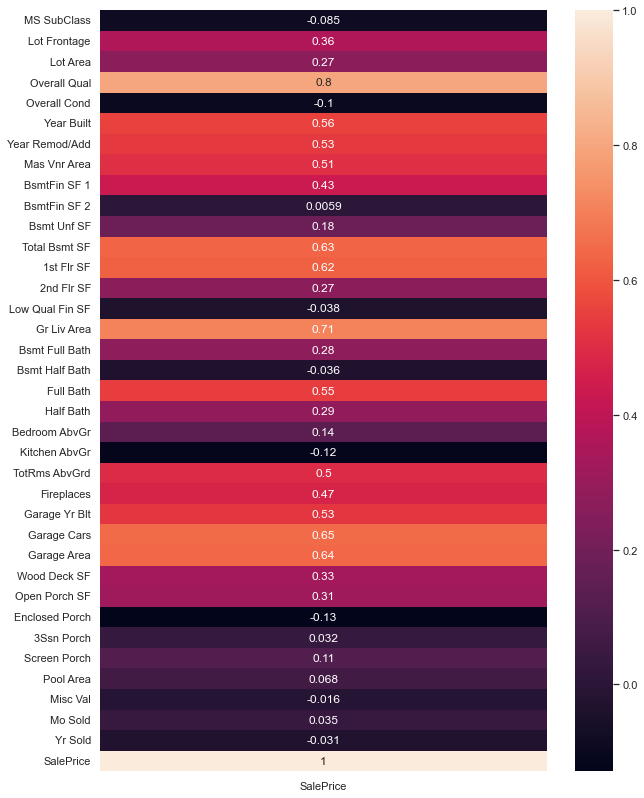

```python
import seaborn as sns
import pandas as pd
import matplotlib.pyplot as plt

file = pd.read_csv('AmesHousing.csv')
# Dropping some variables that aren't important
file.drop(['Order', 'PID'], axis = 1, inplace = True)

fig, ax = plt.subplots(figsize = (10, 14))
saleprice_corr = file.corr()[['SalePrice']]
sns.heatmap(saleprice_corr,
          annot = True,
          ax = ax)
plt.show()
```

Now, this isn't very ordered and it would be easier on the eyes if this was sorted. Let's sort this before plotting:

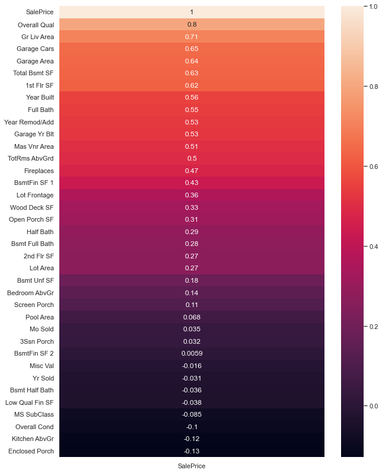

```python
import seaborn as sns
import pandas as pd
import matplotlib.pyplot as plt

file = pd.read_csv('AmesHousing.csv')
# Dropping some variables that aren't important
file.drop(['Order', 'PID'], axis = 1, inplace = True)

fig, ax = plt.subplots(figsize = (10, 14))
saleprice_corr = file.corr()[['SalePrice']]

# Sorting
sorted_saleprice_corr = saleprice_corr.sort_values(by = 'SalePrice',
                                                   ascending = False)

sns.heatmap(sorted_saleprice_corr, annot = True, ax = ax)
plt.show()
```

#### Exercise 18 Pair Plots

Pairwise relationship can be displayed through the use of the pairplot( ) function, which shows possible pairs for each of the variables in the dataset and a univariate plot along the diagonal:

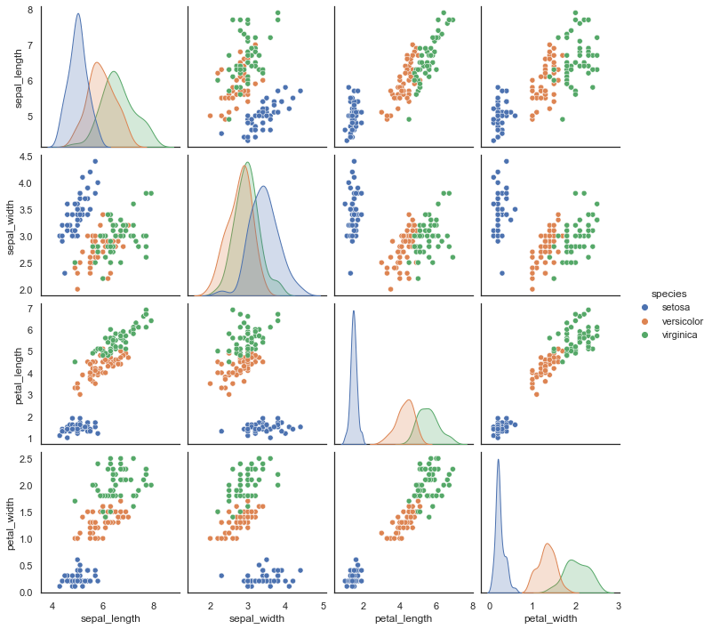

```python
import seaborn as sns
import matplotlib.pyplot as plt

iris = sns.load_dataset("iris")
sns.pairplot(iris, hue = 'species')
plt.show()
```

Here, we've just set the hue to reflect the species from the Iris Dataset. By default, Seaborn chooses a plot type that seems fitting for the given dataset. In this case, it is a scatter plot, with kde plots in the diagonal line.

#### Exercise 19 Change Pair Plot Kind

Let's change the kind argument so that the Pair Plot uses a different type of plot instead of Scatter Plots for non-diagonal comparisons.

These changes will only change the type of info we get, since histograms are very complementary with KDE plots, and Regression Plots are complementary to Scatter Plots:

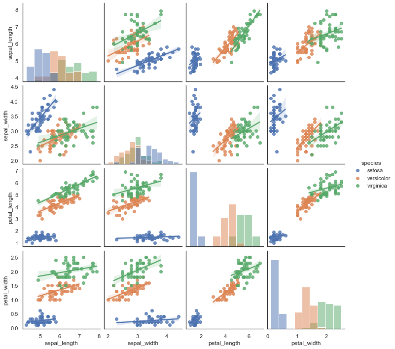

```python
import seaborn as sns
import matplotlib.pyplot as plt

iris = sns.load_dataset("iris")
sns.pairplot(iris,
             hue = 'species',
             kind = 'reg',
             diag_kind = 'hist')
plt.show()
```

Or, we could use KDE as the main kind, and just let Seaborn choose the diagonal plots automatically:

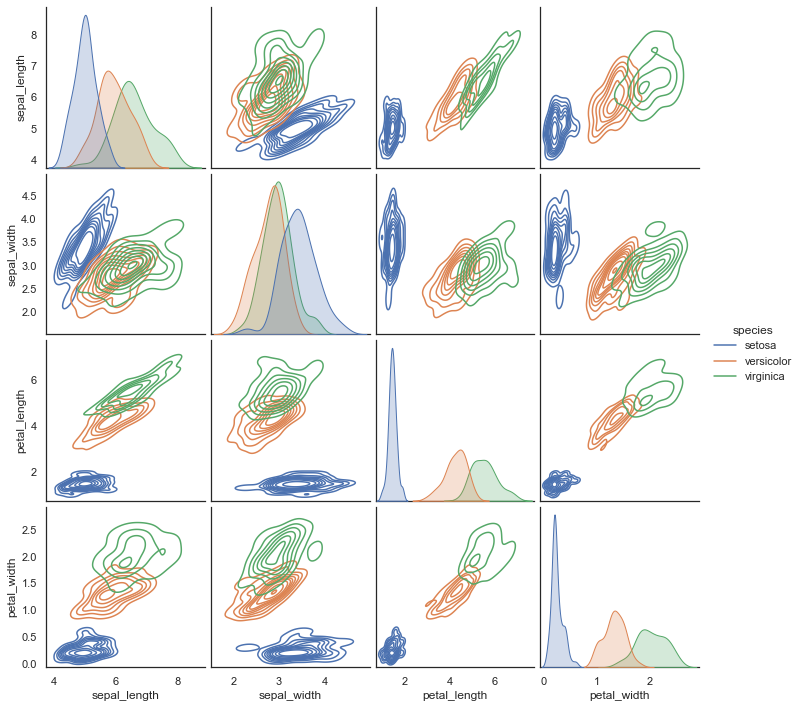

```python
import seaborn as sns
import matplotlib.pyplot as plt

iris = sns.load_dataset("iris")
sns.pairplot(iris,
             hue = 'species',
             kind = 'kde',
             diag_kind = 'auto')
plt.show()
```

Other than kde, reg, and scatter, you can also set the main kind to hist:

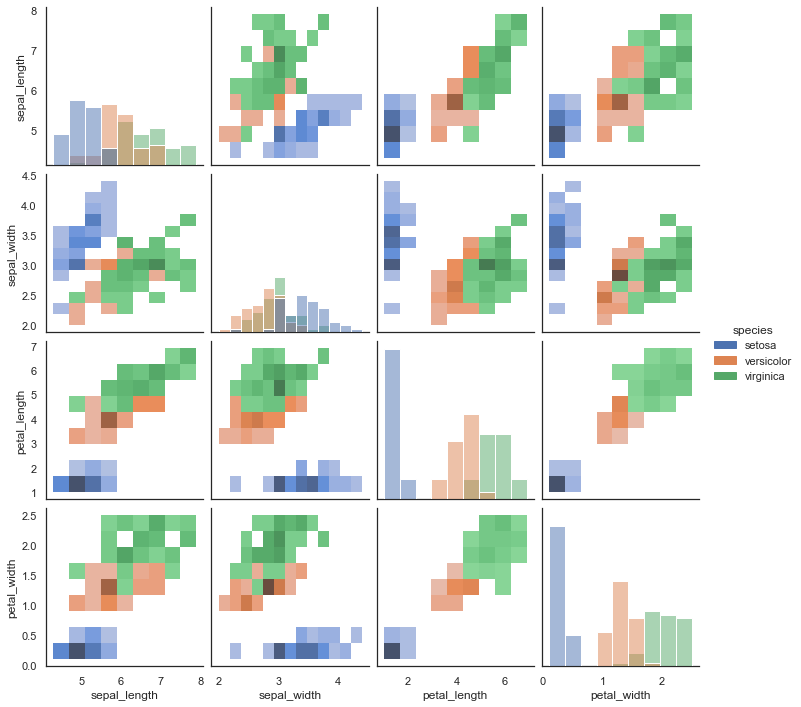

```python
import seaborn as sns
import matplotlib.pyplot as plt

iris = sns.load_dataset("iris")
sns.pairplot(iris,
             hue = 'species',
             kind = 'hist')
plt.show()
```

Revised Date: October 2nd, 2023